# Lab Meeting

13th March 2018

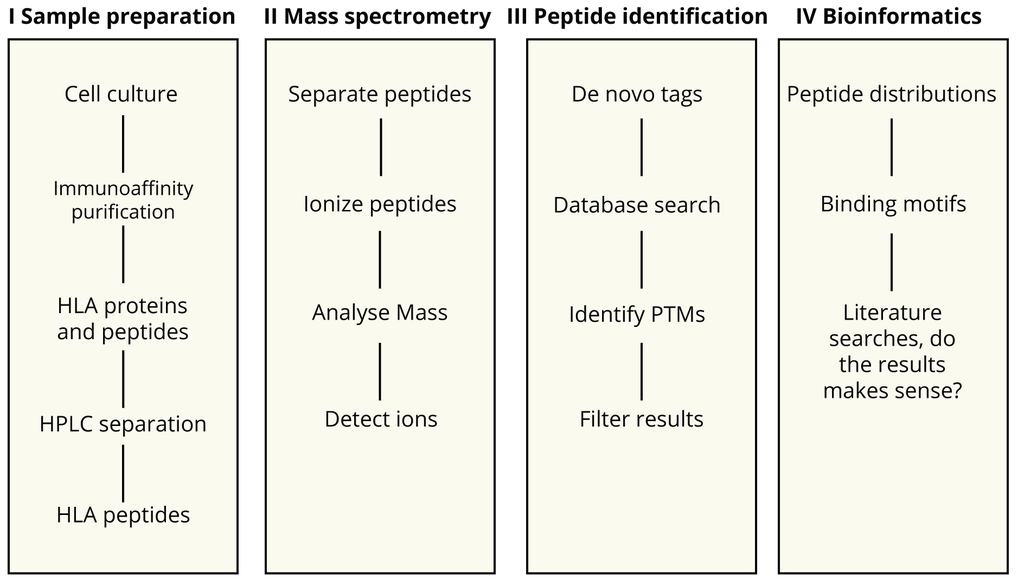

## HaCaTs and DNCB

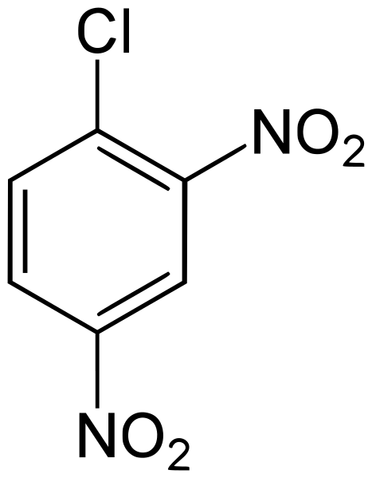

- HaCaT cell line is a spontaneously transformed keratinocyte.
- Homozygous HLA-A*31:01, HLA-B*40:01 / HLA-B*51:01, HLA-C*03 / HLA-C*15
- 2,4-Dinitrochlorobenzene (DNCB) is our model sensitiser.
- DNCB modifies 0.12% Lys, 0.03% Cys and < 0.03% Tyr, His and Arg.

## Peptidomes

Peptidomes provide qualitative information about peptides at the cell surface.

Current methodologies are able to replicate quantities of peptides per assay, but are unable to replicate the peptides themselves very well.

Therefore identifying or predicting *interesting* peptides is difficult due to the variation between assays and the unknown baseline.

However, treatment/control experiments make inferential and predictive questions more tractable.

## Hypotheses

- Sensitiser-modified peptides presented by MHC I directly stimulate the immune system.
- Senitiser modification of proteins alters the MHC I presented reportoire of peptides.

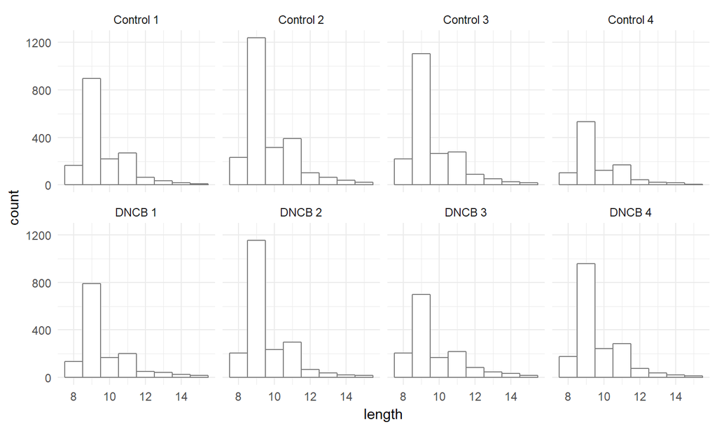

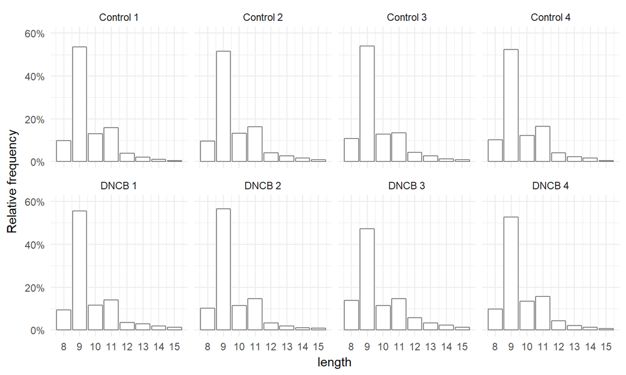

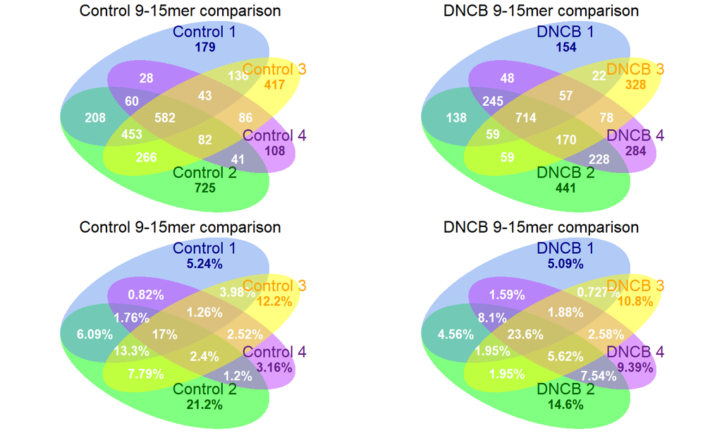

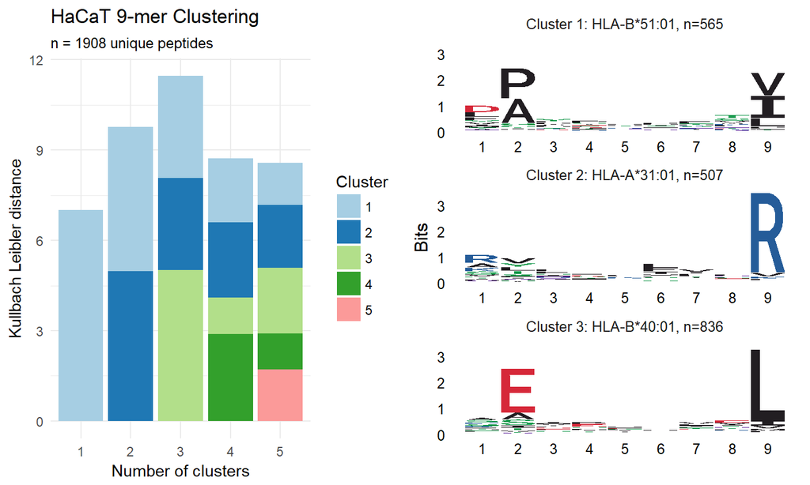

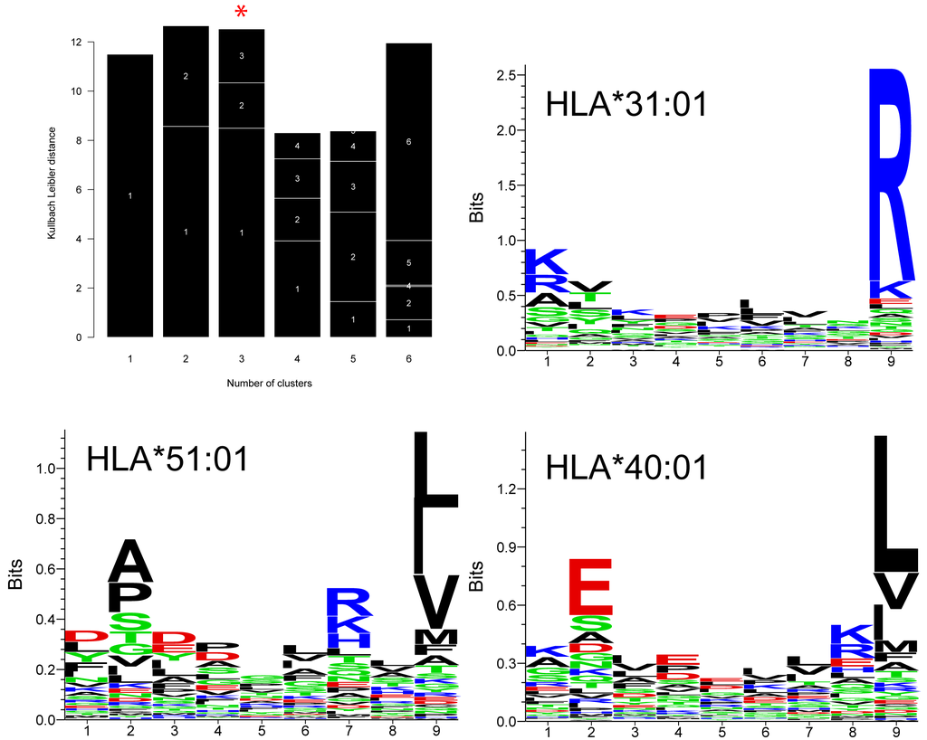

## NetMHC and Gibbs motifs comparison

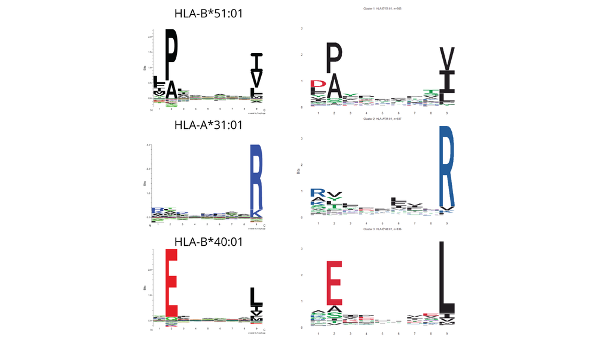

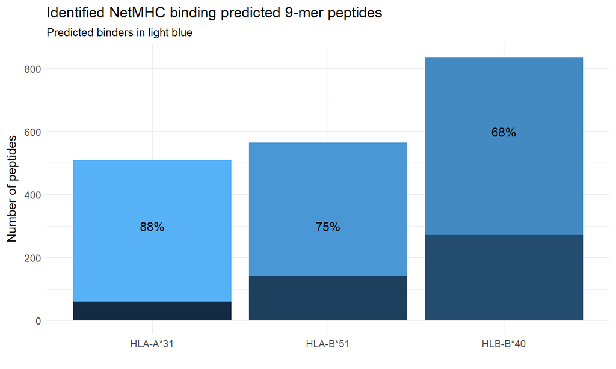

## DNCB modified peptides

| peptide | peptide_nomod | length | exp_name | prot_id |
| --- | --- | --- | --- | --- |
| AETEC(+166.00)RYAL | AETECRYAL | 9 | DNCB 1 | P13646 |
| AETEC(+166.00)RYAL | AETECRYAL | 9 | DNCB 2 | P13646 |
| RFC(+166.00)PFAERTR | RFCPFAERTR | 10 | DNCB 1 | P78417 |
| RFC(+166.00)PFAERTR | RFCPFAERTR | 10 | DNCB 2 | P78417 |

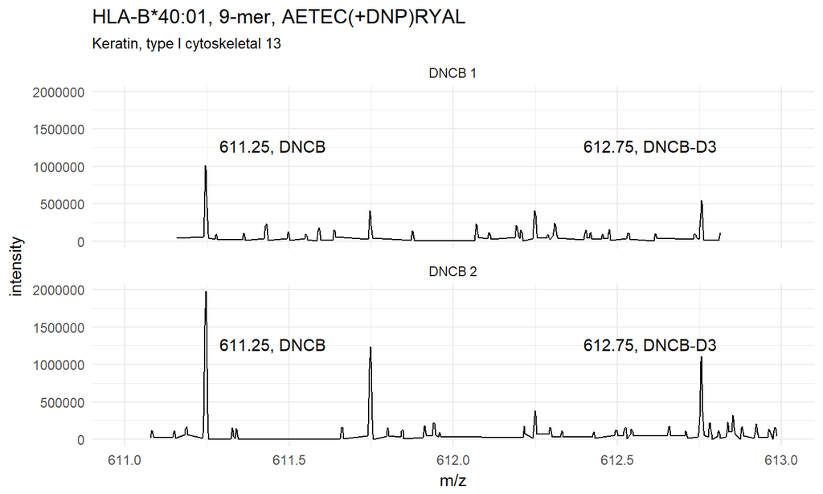

## HLA-B*40:01 9-mer AETEC(+DNP)RYAL

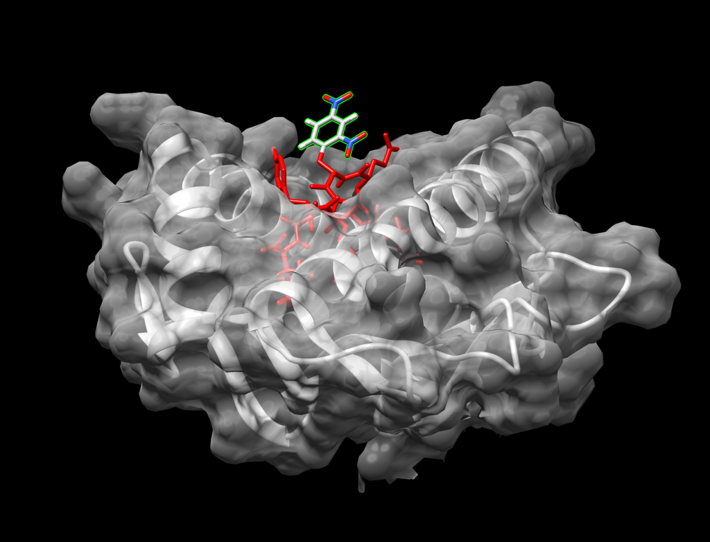

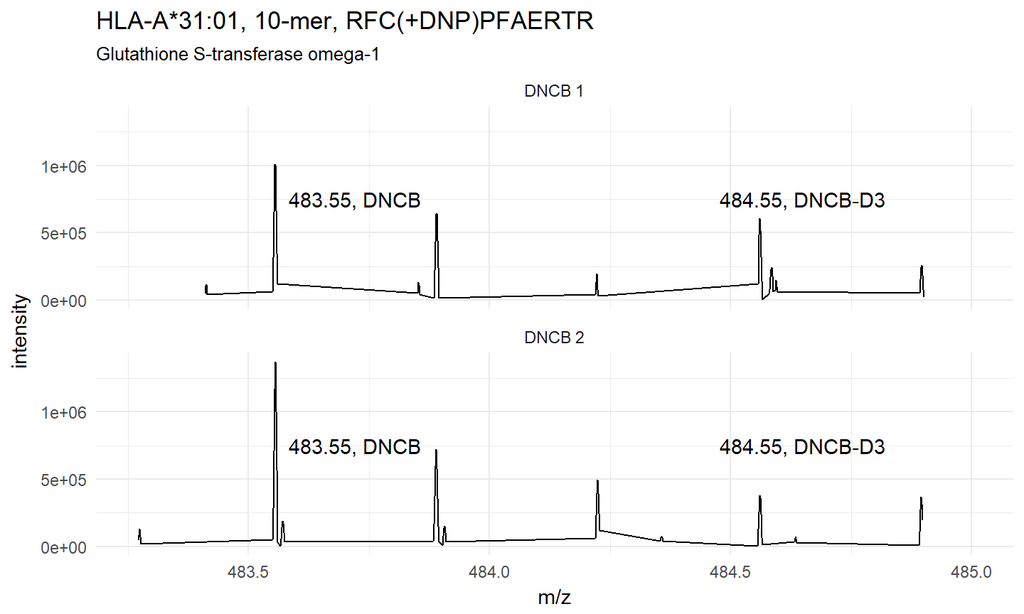

## Glutathione S-transferase omega-1

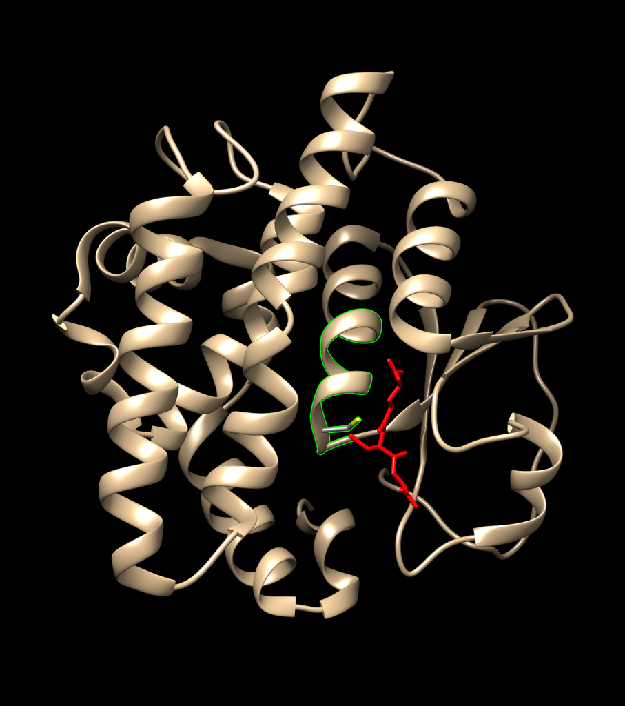

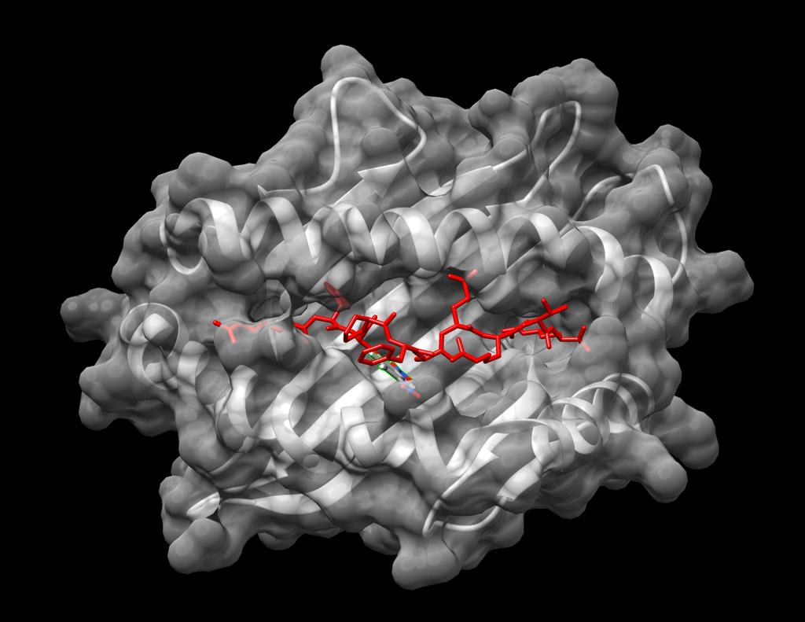

## Predicted Keratin DNCB peptides

Strong binder Rank < 0.5, Weak binder Rank < 2

| Peptide | Length | Allotype | Rank |
| --- | --- | --- | --- |
| RLASYLEKV | 9 | HLA-A*02:01 | 0.09 |
| SLNEELAYM | 9 | HLA-A*02:01 | 0.3 |
| MLLDIKTRL | 9 | HLA-A*02:01 | 0.175 |
| DRLASYLEKV | 10 | HLA-A*02:01 | 0.9 |
| RLKYENELAL | 10 | HLA-A*02:01 | 1.1 |
| KMLLDIKTRL | 10 | HLA-A*02:01 | 1.7 |
| RGVSTCSTR | 9 | HLA-A*31:01 | 0.6 |
| YYKTIEELR | 9 | HLA-A*31:01 | 0.6 |
| KMLLDIKTR | 9 | HLA-A*31:01 | 0.9 |
| RLASYLEKVR | 10 | HLA-A*31:01 | 1 |

[output cut: 19 more lines]

## Predicted GSTO-1 DNCB peptides

Strong binder Rank < 0.5, Weak binder Rank < 2

| Peptide | Length | Allotype | Rank |
| --- | --- | --- | --- |
| YSMRFCPFA | 9 | HLA-A*02:01 | 0.7 |
| MILELFSKV | 9 | HLA-A*02:01 | 0.15 |
| ELFSKVPSL | 9 | HLA-A*02:01 | 1.2 |
| SISMIDYLI | 9 | HLA-A*02:01 | 1.7 |
| SMIDYLIWP | 9 | HLA-A*02:01 | 1.5 |
| LELFSKVPSL | 10 | HLA-A*02:01 | 0.6 |
| ELFSKVPSLV | 10 | HLA-A*02:01 | 2 |
| GSIRIYSMR | 9 | HLA-A*31:01 | 0.2 |
| MRFCPFAER | 9 | HLA-A*31:01 | 0.9 |
| RTRLVLKAK | 9 | HLA-A*31:01 | 0.5 |

[output cut: 23 more lines]

## Story so far…

Development of high quality peptidome methodology.

Evidence for direct presentation of sensitiser modified peptides:

- Peptides identified by mass spectrometry
- Peptides predicted to be strong binders

Evidence for sensitiser effect on cellular detoxification mechanism:

- Modification of Glutathione S-transferase omega-1

Predictions for HLA-A2 sensitiser modified peptides.

## Next steps…

Finish HaCaT peptidome sample processing and analysis.

Process and analyse protein turnover data.

Synthesise peptides to verify spectra and test immunogenecity.

Perform HLA-A2 HaCaT transfectant peptidome/turnover assays.